# The effect of Modyfiying the Nature of Sub-Segments on Channel Impulse Response

The studied configuration is composed of a simple 2 rooms building separated by a subsegment which has a multi subsegment attribute. The attribute of the subsegment can be changed with the method [`chgmss`](http://pylayers.github.io/pylayers/modules/generated/pylayers.gis.layout.Layout.chgmss.html) (change multisubsegment)

1. **Load** the layout
2. **Display** the layout ('s' structure graph)

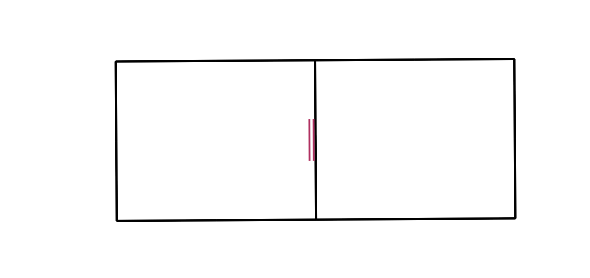

```python
L=Layout('defstr3.ini')
f,a=L.showG('s',subseg=True,figsize=(10,10))
```

1. Changing the material properties of subsegment 1

```python
L.chgmss(1,ss_name=['WOOD','AIR','WOOD'],ss_z =[(0.0,2.7),(2.7,2.8),(2.8,3)])
```

As the Layout structure has been modified it is required to :

1. rebuild the structure.
2. Save the structure post processed data (graph based information)

```python
L.build()
L.save()
```

```
structure saved in  defstr3.str2
structure saved in  defstr3.ini
```

Have a look to the $\mathcal{G}_s$ graph dictionnary.

- $<0$ index nodes are points
- $>0$ index nodes are segments

```python
L.Gs.node
```

```
{-8: {},
 -7: {},
 -6: {},
 -5: {},
 -4: {},
 -3: {},
 -2: {},
 -1: {},
 1: {'connect': [-8, -7],
  'name': 'PARTITION',
  'ncycles': [1, 2],
  'norm': array([-0.999982  , -0.00599989,  0.        ]),
  'ss_name': ['WOOD', 'AIR', 'WOOD'],
  'ss_z': [(0.0, 2.7), (2.7, 2.8), (2.8, 3)],
  'transition': True,
  'z': (0.0, 3.0)},
 2: {'connect': [-8, -2],
  'name': 'WALL',
  'ncycles': [1, 2],
  'norm': array([ 0.99997778,  0.00666652,  0.        ]),
  'transition': False,
  'z': (0.0, 3.0)},
 3: {'connect': [-7, -5],
  'name': 'WALL',
  'ncycles': [1, 2],
  'norm': array([-0.99997775, -0.00667097,  0.        ]),
  'transition': False,
  'z': (0.0, 3.0)},
 4: {'connect': [-6, -1],
  'name': 'WALL',
  'ncycles': [2, 0],
  'norm': array([ 0.99997888,  0.00649986,  0.        ]),
  'transition': False,
  'z': (0.0, 3.0)},
 5: {'connect': [-6, -5],
  'name': 'WALL',
  'ncycles': [2, 0],
  'norm': array([-0.00619988,  0.99998078,  0.        ]),
  'transition': False,
  'z': (0.0, 3.0)},
```

[output cut: 9 more lines]

```
  'norm': array([ 0.99997887,  0.00650149,  0.        ]),
  'transition': False,
  'z': (0.0, 3.0)},
 8: {'connect': [-3, -2],
  'name': 'WALL',
  'ncycles': [1, 0],
  'norm': array([ 0.00639987, -0.99997952,  0.        ]),
  'transition': False,
  'z': (0.0, 3.0)},
 9: {'connect': [-1, -2],
  'name': 'WALL',
  'ncycles': [2, 0],
  'norm': array([-0.00639987,  0.99997952,  0.        ]),
  'transition': False,
  'z': (0.0, 3.0)}}
```

We define now two points which are the termination of a radio link.

```python
tx=np.array([759,1114,1.0])
rx=np.array([767,1114,1.5])
```

```python
L.chgmss(1,ss_name=['WOOD','AIR','WOOD'],ss_z =[(0.0,2.7),(2.7,2.8),(2.8,3)])
L.save()
Lk = DLink(L=L,a=tx,b=rx,Aa=Antenna('Omni'),Ab=Antenna('Omni'))
```

```
structure saved in  defstr3.str2
structure saved in  defstr3.ini
```

```python
Lk.a=np.array([759,1114,1.0])
Lk.b=np.array([767,1114,1.5])
```

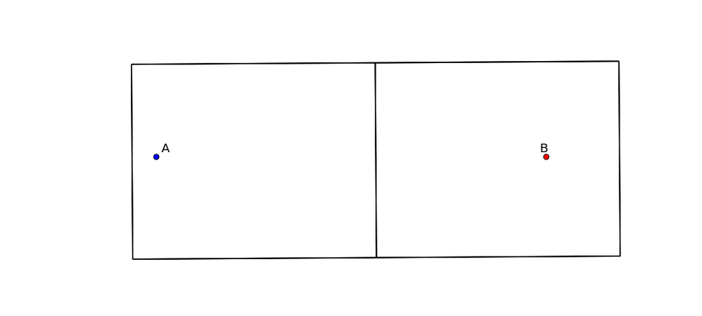

```python
f,a=Lk.show()
```

On the figure above, we can see the Tx and Rx each placed in a different room appart from a wall with a subsegement placed in the middle. Then for evaluating the radio link, simply type:

```python
ak,tauk=Lk.eval(force=['sig','ray','Ct','H'])
```

```
Signatures'> from 2_1_3 saved
Rays'> from 3_0_1 saved
Ctilde'> from 0_1_0 saved
Tchannel'> from 0_1_0_0_0_1_1 saved
```

At that point the channel has been evaluated and all the data stored in an `hdf5` file

## The different members of the link are

The Signature of the radio channel is in `Lk.Si`, the 3D rays are in `Lk.R`, the propagation channel is in `Lk.C` and the transmission channel is in `Lk.H`

```python
Lk.R
```

```
Rays3D
----------
1 / 1 : [0]
2 / 6 : [1 2 3 4 5 6]
3 / 18 : [ 7  8  9 10 11 12 13 14 15 16 17 18 19 20 21 22 23 24]
4 / 37 : [25 26 27 28 29 30 31 32 33 34 35 36 37 38 39 40 41 42 43 44 45 46 47 48 49
 50 51 52 53 54 55 56 57 58 59 60 61]
5 / 42 : [ 62  63  64  65  66  67  68  69  70  71  72  73  74  75  76  77  78  79
  80  81  82  83  84  85  86  87  88  89  90  91  92  93  94  95  96  97
  98  99 100 101 102 103]
6 / 26 : [104 105 106 107 108 109 110 111 112 113 114 115 116 117 118 119 120 121
 122 123 124 125 126 127 128 129]
-----
ni : 581
nl : 1292
```

```python
Lk.C
```

```
Ctilde
---------
(130, 181)
Nray : 130
fmin(GHz) : 2.0
fmax(GHz): 11.0
Nfreq : 181
```

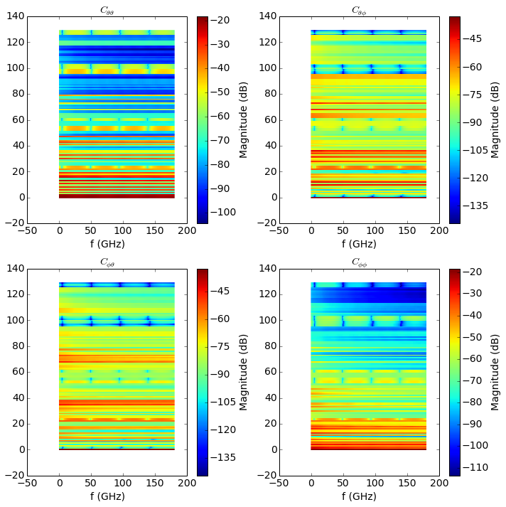

```python
f = plt.figure(figsize=(10,10))
f,a=Lk.C.show(cmap='jet',fig=f,typ='l20')
```

```python
Lk.H
```

```
freq :2.0 10.0 161
shape  :(130, 161)
tau :26.7186992365 73.2944728109
dist :8.01560977094 21.9883418433
Friis factor -j c/(4 pi f) has been applied
```

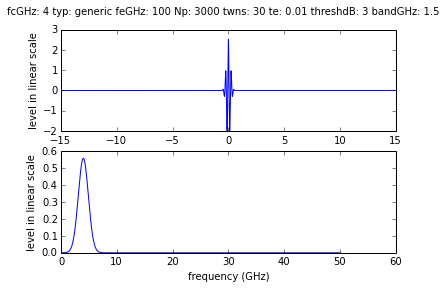

```python
fGHz=np.arange(2,6,0.5)
wav = wvf.Waveform(fcGHz=4,bandGHz=1.5)
wav.show()
```

```python
cir = Lk.H.applywavB(wav.sf)
```

```
 array([[<matplotlib.axes.AxesSubplot object at 0x7fc729cdb2d0>]], dtype=object))
```

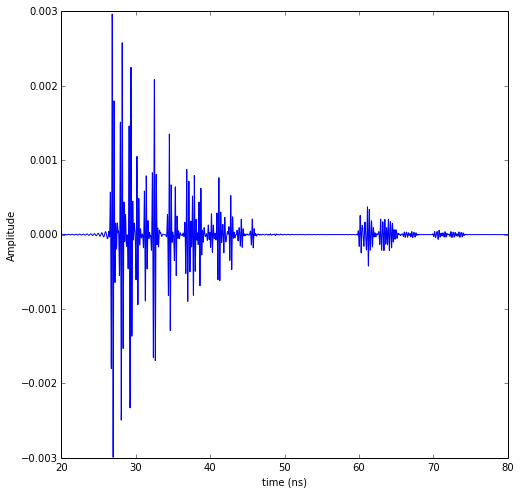

```python
cir.plot(typ=['v'],xmin=20,xmax=80)
```

```
structure saved in  defstr3.str2
structure saved in  defstr3.ini
Signatures'> from 2_1_3 saved
Rays'> from 3_0_1 saved
Ctilde'> from 0_1_0 saved
Tchannel'> from 0_1_0_0_0_1_1 saved
```

```
 array([[<matplotlib.axes.AxesSubplot object at 0x7fc72a3887d0>]], dtype=object))
```

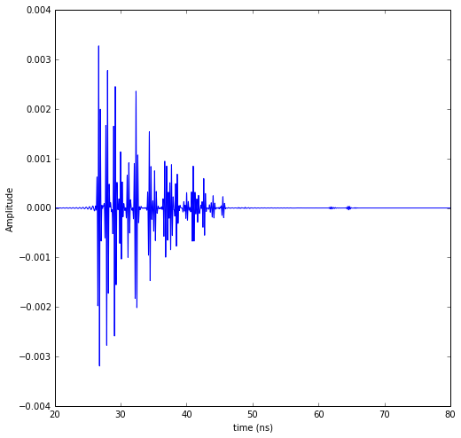

```python
layer = ['AIR','AIR','AIR']
L.chgmss(1,ss_name=layer)
L.Gs.node[1]['ss_name']=layer
L.g2npy()
L.save()
Lk = DLink(L=L,a=tx,b=rx,Aa=Antenna('Omni'),Ab=Antenna('Omni'))
Lk.a=tx
Lk.b=rx
Lk.eval(force=['sig','ray','Ct','H'])
cirair = Lk.H.applywavB(wav.sf)
cirair.plot(typ=['v'],xmin=20,xmax=80)
```

```
structure saved in  defstr3.str2
structure saved in  defstr3.ini
Signatures'> from 2_1_3 saved
Rays'> from 3_0_1 saved
Ctilde'> from 0_1_0 saved
Tchannel'> from 0_1_0_0_0_1_1 saved
```

```
 array([[<matplotlib.axes.AxesSubplot object at 0x7fc72a13e350>]], dtype=object))
```

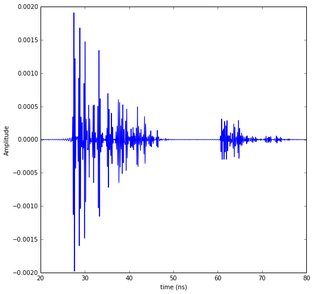

```python
layer = ['PARTITION','PARTITION','PARTITION']
L.chgmss(1,ss_name=layer)
L.Gs.node[1]['ss_name']=layer
L.g2npy()
L.save()
Lk = DLink(L=L,a=tx,b=rx,Aa=Antenna('Omni'),Ab=Antenna('Omni'))
Lk.a=tx
Lk.b=rx
Lk.eval(force=['sig','ray','Ct','H'])
cirpart = Lk.H.applywavB(wav.sf)
cirpart.plot(typ=['v'],xmin=20,xmax=80)
```

```python
type(cirair)
```

```
pylayers.signal.bsignal.Usignal
```

```
structure saved in  defstr3.str2
structure saved in  defstr3.ini
Signatures'> from 2_1_3 saved
Rays'> from 3_0_1 saved
Ctilde'> from 0_1_0 saved
Tchannel'> from 0_1_0_0_0_1_1 saved
```

```
 array([[<matplotlib.axes.AxesSubplot object at 0x7fc728489c50>]], dtype=object))
```

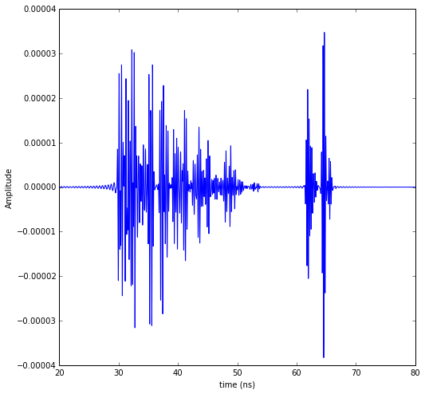

```python
layer = ['METAL','METAL','METAL']
L.chgmss(1,ss_name=layer)
L.Gs.node[1]['ss_name']=layer
L.g2npy()
L.save()
Lk = DLink(L=L,a=tx,b=rx,Aa=Antenna('Omni'),Ab=Antenna('Omni'))
Lk.a=tx
Lk.b=rx
Lk.eval(force=['sig','ray','Ct','H'])
cirmet = Lk.H.applywavB(wav.sf)
cirmet.plot(typ=['v'],xmin=20,xmax=80)
```

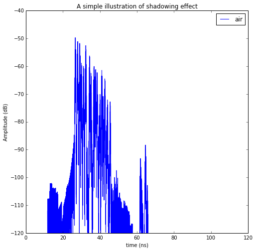

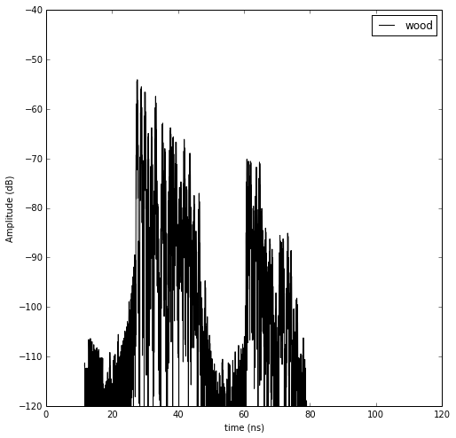

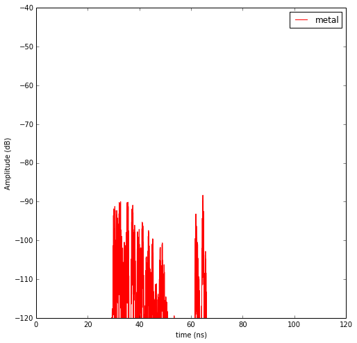

```python
#fig2=plt.figure()
f,a=cirair.plot(typ=['l20'],color='b')
plt.axis([0,120,-120,-40])
plt.title('A simple illustration of shadowing effect')
plt.legend(['air'])
f,a=cirpart.plot(typ=['l20'],color='k')
plt.axis([0,120,-120,-40])
plt.legend(['wood'])
f,a=cirmet.plot(typ=['l20'],color='r')
plt.axis([0,120,-120,-40])
plt.legend(['metal'])
```

We have modified successively the nature of the 3 surfaces in the sub segment placed in the sepataion partition. The first was AIR, the second WOOD and the third METAL. As the subsegment is placed on the LOS path the blockage effect is clearly visible.  
The chosen antennas were omnidirectional `Antenna('Omni')`

```python
from IPython.core.display import HTML

def css_styling():
    styles = open("../styles/custom.css", "r").read()
    return HTML(styles)
css_styling()
```